# pgc-perf-opt Pipeline

A SARS-CoV-2 Variant Discriminator using Unsupervised Machine Learning (UML) Techniques

Project Lead:** Mark Joseph Garrovillas, RCh **Interns:** Brylle Joshua Logroño, John Matthew Felices, Yenzy Urson Hebron

The **pgc-perf-opt pipeline** can produce rich and intuitive clusterings of SARS-CoV-2 genome samples by treating $k$-mer count data with the following dimensionality reduction and clustering techniques:

- Principal components analysis (PCA)
- t-distributed stochastic neighbor embedding (t-SNE)
- Uniform manifold approximation (UMAP), and
- Agglomerative clustering (AGNES).

The workflow is well-tested on odd $k$-mer count matrices where $k = \{3, 5, 7\}$ and with variant stratum sizes of $\textrm{strat_size}\in[1,2000]$ for the sampling. Higher values for these parameters would require larger processing power, and scaling up to the complete Philippine dataset (`country_exposure = "Philippines" && strat_size >= 25000`) is indeed an ongoing objective. Do note that most parameters of the pipeline are highly customizable. Aside from a project-specific [Docker image](https://hub.docker.com/r/yshebron/pgc-perf-opt), the pipeline’s reproducibility were also guaranteed by making the source code adapt to any R 4.3.1 environment. A `renv` and `shiny` setup is also under consideration.

All paths used and discussed are relative to the project root, which is given by the directory where the project is cloned into or where this document and `pgc-perf-opt.Rproj` resides (`getwd() = "C:/UPDLabs/pgc-perf-opt"`). For the codebase, see `code`. For the data sources, overviews, and artifacts, see `data`. For the outputs, see `results` and `presentations`.

# Primer on Data Formats

Before discussing the actual pipeline, one must first be familiar with the data that will be processed. The data will undergo the following transformations within the simplified pipeline below:

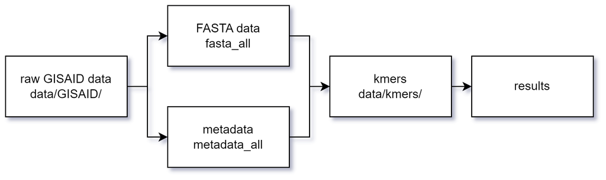

We shall now discuss the format in each stage of the data, ignoring the data overview and results.

## Stage 2B: Metadata

## Stage 3: $k$-mers

[interactive chart not shown]

With these in mind, we may now proceed to the setup.

# 1. Pipeline Setup

## A. Load Packages

If this project is not running in a project-specific environment (e.g. the custom-made pgc-perf-opt Docker image), then the following packages will also have to be installed for the pipeline to work. Else, this section will only deal with loading the dependencies.

We use the CRAN repository as our main source.

```r
options(repos = "https://cloud.r-project.org/")
```

We use the `pacman` package to conveniently organize our project’s packages.

```r
if (!require("pacman"))
  install.packages("pacman")
library(pacman)
```

If we are not running on a tailor-made environment, we also install `xml2` in advance to prepare for Tidyverse installation in Linux. Note that in Windows RStudio, this is installed by default. This is also a good time to demonstrate how our development life cycle took care to maintain compatibility between Linux and Windows, and this is most evident in the pipeline and in `code/R/helper.R::write_to_log`.

```r
if (pacman::p_detectOS() == "Linux" && !pacman::p_exists(xml2, local = TRUE)) {
  install.packages("xml2", dependencies = TRUE, INSTALL_opts = c("--no-lock"))
  pacman::p_load(xml2)
}
```

Let us use `pacman` to load add-on packages as desired. We omit redundant dependencies such as `dplyr` and `ggplot2` which are already in the `tidyverse`.

```r
pacman::p_load(plyr, GGally, ggthemes, ggvis, plotly, psych,
               htmlwidgets, rio, markdown, shiny, tidyverse,
               ape, seqinr, kmer, validate, gsubfn,
               Rtsne, tsne, umap, factoextra, scales,
               RColorBrewer, ggfortify, devtools,
               ggdendro, dendextend, cluster, colorspace,
               microbenchmark, data.table, highcharter)

# ggbiplot is installed separately via install_github
if (!require(ggbiplot))
  devtools::install_github("vqv/ggbiplot", upgrade = FALSE, quiet = TRUE)
pacman::p_load(ggbiplot)
```

Remarks on some of the dependencies:

- `ape`: for reading and writing FASTA files in `DNAbin` format.
- `seqinr`: an `ape` alternative, reads and writes FASTA files in `char` format.
- `kmer`: for generating $k$-mer counts, works more efficiently with `DNAbin`.
- `validate`: for the `%vin%` membership operator.
- `gsubfn`: for destructuring more than one return value.
- `Rtsne`, `tsne`, `umap`, `ggdendro`, and `dendextend`: for accessing t-SNE, UMAP, and AGNES algorithms.
- `devtools`: supports `install_github` for installing `ggbiplot`.

## B. Load Sources

Let us fetch functions from the files in `code/R`. This requires that this notebook is loaded using the pgc-perf-opt `.Rproject` file at the root of the repository.

```r
source("code/R/helper.R")
source("code/R/preprocess.R")
source("code/R/kmer-analysis.R")
source("code/R/dim-reduce.R")
source("code/R/clustering.R")
```

## C. Set Parameters

Adjust the parameters that will control the flow and behavior of the pipeline. Pay attention to the parameter defaults in both function definitions and in the global environment. Parameter hypertuning may also be needed for the dimensionality reduction and clustering techniques. Currently set to only use Philippine SARS-CoV-2 data (see `data/GISAID`), the workflow filters out samples collected outside the country (see `country_exposure` parameter), but it can be set to use other countries — among many other variable options — in the parameters section of the Setup.

*NOTE:* This section may also guide the construction of a pgc-perf-opt dashboard.

### Pipeline General Parameters

These general parameters are shared by multiple routines.

#### Code

```r
seed <- 1234
stamp <- get_time()
write_fastacsv <- TRUE
kmer_list <- c(7)
strat_size <- 100
include_plots <- TRUE
```

### preprocess.R Parameters

These parameters control how the raw GISAID data is processed from extraction to preparing the FASTA and metadata files for downstream analysis.

- Recall that due to GISAID’s terms of use, GISAID data must be manually added to `gisaid_data_path` which is most likely empty in a freshly cloned pgc-perf-opt project.
- We adopt the following convention to path I/O:
  - If a path variable is suffixed with `write_path`, the path and its children are *write-only*.
  - If a path variable is suffixed with `data_path`, the path and its children are *read-or-write*.

#### Code

```r
gisaid_data_path <- "data/GISAID"
gisaid_extract_path <- "data/GISAID/datasets"
country_exposure <- "Philippines"
interm_write_path <- "data/interm"
compile_write_path <- "data/overview"
```

#### Description

- `gisaid_data_path`: Where to read raw GISAID data from, assuming this contains GISAID tar files.
- `gisaid_extract_path`: Where to extract raw GISAID data to.
- `country_exposure`: Which country to filter for in `preprocess.R::get_sample()`.
- `interm_write_path`: Where to write intermediate data, e.g. fasta_all_x.fasta and metadata_all_x.csv with various suffixes.
- `compile_write_path`: Where to write data overviews to such as authors and submitting labs along with their submission counts.
  - Includes treemaps and heatmaps with various metadata hiearchies.

### kmer-analysis.R Parameters

```r
# Where to write (then read) kmers data from.
# Shared by dim-reduce.R routines.
kmers_data_path <- "data/kmers"
```

### dim-reduce.R Parameters

These parameters control the dimensionality reduction algorithms. Hypertuning these parameters may be needed to achieve good and efficient clustering. Please consult `code/R/dim-reduce.Rmd` for more in-depth explanation on `dim-reduce.R`. Also see `?tsne::tsne` and `?umap::umap` for more information.

#### Code

```r
# dim-reduce.R::dim_reduce() main parameters
dr_write_path <- "results/dim-reduce/R"
tsne_perplexity <- 40
tsne_max_iter <- 1000
tsne_initial_dims <- 50
umap_n_neighbors <- 15
umap_metric <- "euclidean"
umap_min_dist <- 0.1
dr_color <- "variant"
dr_shape <- "year"

# dim-reduce.R::dim_reduce()::pre_reduce auxiliary parameters
dr_factor1 <- NULL
dr_values1 <- NULL
dr_factor2 <- NULL
dr_values2 <- NULL
```

#### Description

Main Parameters: These are primarily filters that control the hyperparameters of the dimensionality reduction algorithms.

- `dr_write_path` (`str`): Where to write results of dimensionality reduction.
- `tsne_perplexity` (`int`): Guess about the number of close neighbors each point has.
- `tsne_max_iter` (`int`): Bounds the number of `tsne` iterations
  - Defaults to 1000, but may be increased to get closer to actual onvergence.
- `tsne_initial_dims` (`int`): Number of dimensions to “start” from, more aggressively collapsing higher dimensions.
- `umap_n_neighbors` (`int`): Constrains the size of the local neighborhood where the manifold structure of the data may be learned.
- `umap_metric` (`str`): Determines how distances between data points are computed.
  - Available metrics are: euclidean, manhattan, cosine, pearson, and pearson2.
- `umap_min_dist` (`int`): Determines how close points appear in the final layout.
- `dr_color`: Determines which metadata attribute to use for assigning colors to the clusters.
  - See metadata columns for available values.
- `dr_shape`: Determines which metadata attribute to use for assigning shapes to the clusters.
  - See metadata columns for available values.

Note that `dr_color` and `dr_shape` work together to create two-level clustering for the dimensionality reduction visualizations.

Auxiliary Parameters: These are optional parameters (can be set to `NULL`) for applying custom filters to the $k$-mer + metadata data frame, specifically `kmers[[i]]`.

### clustering.R Parameters

```r
agnes_write_path <- "results/dendrogram"
```